# Conservation History as Living Context

Week 2 Monday — Chapter 2

NRES 315: Human Dimensions of Fish and Wildlife Management

2026-08-28

## Today’s question

How do earlier eras of fish and wildlife management still shape a decision made now?

History explains the **institutions, funding, laws, professional habits, and public expectations** a manager inherits.

Source: Chapter 2, §§2.1–2.2.

## What you should be able to do

By the end of today, you should be able to:

- identify the defining priority and social context of each historical era;
- explain how an earlier era left a legacy for a current decision; and
- use a human-dimensions question to examine that legacy rather than treating it as neutral or inevitable.

Source: Chapter 2, guiding questions; §2.2.

## History asks more than “what happened?”

**Priority**

What problem seemed most urgent?

**Context**

Which values, economics, and politics shaped the response?

**Legacy**

What remains in current management?

Conservation history traces changing relationships among people, species, habitats, and institutions.

Source: Chapter 2, §§2.1–2.2.

## Conservation history is cumulative

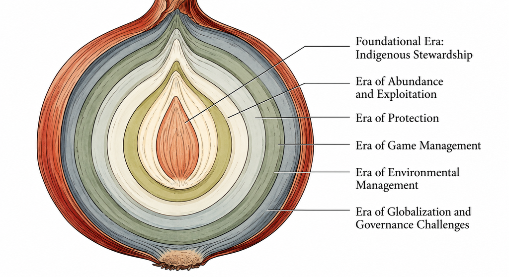

Source: Chapter 2, Figure 2.1 and §§2.2.1–2.2.8.

## A timeline tells order; history explains inheritance

**Timeline question**

What came next?

**Historical question**

What did this era leave behind for today’s decisions?

An inherited legacy might be a legal framework, a source of agency revenue, an idea about expertise, or a pattern of inclusion and exclusion.

Source: Chapter 2, §2.2.

## Indigenous stewardship is the first layer

The history of North American fish and wildlife management begins long before European colonization.

## Indigenous stewardship: reciprocal responsibility

Many Indigenous nations developed place-based stewardship systems over millennia.

- Humans are part of relationships with living and nonliving beings.
- Stewardship can be guided by respect, relevance, responsibility, and reciprocity.
- Knowledge is created and shared across generations through oral and visual traditions.

Source: Chapter 2, §2.2.1.

## “Pristine wilderness” is an incomplete history

Framing conservation history as beginning with Muir or Roosevelt overlooks the active management of pre-colonial landscapes.

Landscapes were actively shaped by Indigenous peoples: Karuk and Yurok controlled fire; Lakota and Blackfeet developed bison-harvest practices; Lummi and Yakama created salmon fisheries.

Ignoring that stewardship erases Indigenous cultures and can help justify removal from ancestral lands.

Source: Chapter 2, §2.2.1.

## The legacy continues through governance

Contemporary collaboration and co-management include:

- Mille Lacs Lake fishery management and treaty-rights partners;
- Menominee forest management and a seventh-generation responsibility;
- Indigenous input to the Alexander Archipelago wolf assessment; and
- Hawaiian marine governance that integrates customary values.

Source: Chapter 2, §2.2.1.

## Abundance became a utilitarian premise

1600–1850: European settlers commonly perceived North American resources as effectively endless.

## Era of Abundance: freedom, opportunity, and commodities

European restrictions on hunting had often served monarchs and aristocrats. In North America, fewer restrictions helped make wildlife seem like:

- a freely usable resource;
- a symbol of freedom and opportunity; and
- a source of profit in market hunting, trapping, and the fur trade.

Perceived abundance helped normalize a belief that use did not require long-term restraint.

Source: Chapter 2, §2.2.2.

## Exploitation made the limits visible

1850–1900: industrial-scale commerce in “fin, feather, and fur” outpaced weak conservation institutions.

## Era of Exploitation: short-term use, lasting damage

**Conditions**

- few regulatory frameworks;
- industrial-scale markets;
- new harvest technologies; and
- westward expansion.

**Consequences**

- depleted deer and beaver;
- reduced predator ranges;
- declining salmon; and
- near extermination of bison.

Source: Chapter 2, §2.2.3 and Figure 2.2.

## Bison shows why a social history matters

The near extermination of bison reflected a convergence of:

- industrial hide harvest and market demand;
- military and government campaigns against Indigenous peoples; and
- westward expansion.

Ecological decline is often inseparable from political power, economic systems, and human relationships.

Source: Chapter 2, §2.2.3.

## Protection changed the rules

1900–1930: overharvest and species decline produced organized advocacy, new laws, and new conservation institutions.

## Era of Protection: from commodity to public concern

The passenger pigeon and Carolina parakeet were extinct; bison had fallen to roughly a thousand animals by the 1890s.

- Harriet Hemenway and Minna Hall organized opposition to the plume trade and helped establish the Massachusetts Audubon Society.
- The Lacey Act (1900) restricted interstate commerce in illegally taken wildlife.

Source: Chapter 2, §2.2.4 and Figure 2.3.

## Protection required cooperation beyond one state

The Migratory Bird Treaty Act (1918):

- followed a U.S.–Great Britain treaty acting on Canada’s behalf;
- made most migratory birds illegal to hunt, capture, or sell; and
- recognized that migratory species require management at a continental scale.

Source: Chapter 2, §2.2.4.

## Game management built a profession

1930–1960: management moved from reactive protection toward proactive, science-based restoration and sustainable use.

## Era of Game Management: a durable funding legacy

| Program | Revenue source | What it supported |
| --- | --- | --- |
| Pittman–Robertson Act (1937) | Excise tax on sporting arms and ammunition | State wildlife restoration, habitat, research, public hunting areas |
| Dingell–Johnson Act (1950) | Excise tax on certain fishing tackle | Sport-fish restoration and related state projects |

The model linked purchases by hunters, anglers, and later boaters to public conservation benefits.

Source: Chapter 2, §2.2.5.

## Expertise, education, and organizations expanded

Professionalization created a durable infrastructure:

- Leopold’s *American Game Policy* (1930) and *Game Management* (1933);
- a Wisconsin wildlife degree program and Cooperative Wildlife Research Units;
- The Wildlife Society and Ducks Unlimited (both 1937); and
- a land ethic that framed conservation as a moral duty of care.

Source: Chapter 2, §2.2.5.

## A successful model can still be narrow

The game-management era elevated game and sportfish, but it also created costs:

- nongame species and broader ecological problems received less priority;
- public outreach often remained one-way education; and
- programs could displace Indigenous communities, overlook knowledge, and reproduce racial and economic exclusions.

Source: Chapter 2, §2.2.5.

## Environmental management broadened the frame

1960–1990: conservation increasingly addressed ecosystems, environmental harm, public participation, and accountability.

## Era of Environmental Management: systems, not isolated species

Rachel Carson’s *Silent Spring* (1962) helped connect pesticide use to ecological and human-health consequences.

The management question widened: How do habitats, ecosystems, pollution, and human systems interact?

The social question widened too: Who participates, and how are institutions accountable?

Source: Chapter 2, §2.2.6.

## Law made participation and accountability more visible

**National Environmental Policy Act (1970)**

Institutionalized public participation and accountability in environmental decision-making.

**Endangered Species Act (1973)**

Made protection of imperiled species a national conservation priority.

Source: Chapter 2, §2.2.6.

## Human dimensions became a named professional field

Early information from hunters often served “surrogate biology”: estimating harvest and population measures.

The emerging field added different questions: landowner–hunter conflict, recreation experiences, wildlife values, economic effects, and public participation.

In 1973, a North American Wildlife and Natural Resources Conference session formally introduced “human dimensions in wildlife programs.”

Source: Chapter 2, §2.2.6, Boxes 2.1–2.2.

## Institutionalization changed who agencies could learn from

| Development | What it made more possible |
| --- | --- |
| Missouri hired Dan Witter (1978) | Full-time agency human-dimensions expertise |
| Cornell's Human Dimensions Research Unit | Dedicated university research capacity |
| Yale's Human Dimensions of Wildlife Study Group | Professional scholarly community |
| Later journals and university programs | A recognized field and shared methods |

Source: Chapter 2, §2.2.6, Boxes 2.1–2.2.

## Globalization and international governance change the scale

1990–present: conservation problems and solutions increasingly cross ecological, political, and social boundaries.

## Global challenges require connected governance

Contemporary conservation faces interconnected challenges:

- biodiversity loss and landscape fragmentation;
- wildlife trade and invasive species;
- climate change and shifting species distributions; and
- urbanization and changing relationships with wildlife.

When a problem crosses boundaries, management needs cooperation among institutions, communities, and publics at multiple scales.

Source: Chapter 2, §2.2.7.

## International frameworks meet local knowledge

Global agreements and local governance operate together:

- CBD and CITES help align national and local work with global priorities.
- The European Union’s Common Fisheries Policy uses public engagement and adaptive management.
- Namibia’s community conservancies connect local knowledge, livelihoods, wildlife coexistence, and conservation goals.

Source: Chapter 2, §2.2.7.

## Modern challenges reveal the accumulated layers

The history becomes useful when it helps diagnose a present conservation problem.

## A present decision is social, ecological, and institutional

For urban wildlife, predator reintroduction, habitat restoration, or climate adaptation, a manager may need to ask:

- Which publics experience benefits, costs, or risk?
- Which authorities and knowledge systems have a role?
- What history shapes funding, trust, access, or participation?
- What new challenges make older approaches insufficient?

Source: Chapter 2, §2.2.8.

## Technology adds capacity—and new questions

**New possibilities**

GIS, remote sensing, data science, iNaturalist, eBird, and social media can expand research and participation.

**New responsibilities**

Managers must consider access, data quality, privacy, misinformation, and who benefits from technology.

Source: Chapter 2, §2.2.8.

## Practice: trace one legacy forward

With a partner, choose one Chapter 2 era. Prepare a 45-second explanation:

1. What priority, institution, or assumption is associated with that era?
2. How could it still shape a current fish or wildlife decision?
3. What human-dimensions question would a manager ask before treating that legacy as neutral or inevitable?

Source: Chapter 2, §2.2.

## From history to public responsibility

History shows that management inherits layered priorities and institutions.

Wednesday asks the next question:

> **For whom should those institutions act, and how are they accountable?**

Source: Chapter 2, §§2.2–2.3; Chapter 3, §§3.1–3.3.

## Exit check

Complete both statements:

1. One current management decision is shaped by the legacy of ______ because ______.
2. A human-dimensions question about that legacy would ask ______.

Source: Chapter 2, §§2.2–2.3.